## ST445 Final Project 2021/22

Candidate Number: 12210, 26889, 31849

# The Truth Behind NBA Salaries

- 1 Introduction
  - 1.1 A special market
  - 1.2 Literature review
- 2 The Data
  - 2.1 Introducing the data
  - 2.2 Obtaining the data
  - 2.3 Overview of salaries
- 3 What affects salary? Is the NBA a meritocracy?
  - 3.1 Performance and experience
  - 3.2 Do positions matter
  - 3.3 Domestic vs Foreign: Is there discrimination or favouritism?
  - 3.4 Do some teams pay more than others?
- 4 Quantifying the Relationship: Regression Analysis
  - 4.1 Multiple linear regression
  - 4.2 Correlation tests
  - 4.3 K-means clustering
- 5 The Evolution of Salary from 2007-2017
  - 5.1 Data acquisition
  - 5.2 Trend of salary over time
  - 5.3 Inequality over time
- 6 Conclusion
- 7 References
- 8 Contribution

## Setting Up

For this computational report, the following packages and dependencies are needed.

```python
# Importing relevant dependencies
from IPython.display import Image
from urllib.request import urlopen
from bs4 import BeautifulSoup
import pandas as pd
import requests
import re
from bs4 import Comment
import numpy as np
import folium
import matplotlib.pyplot as plt
import matplotlib.ticker as ticker
%matplotlib inline
import seaborn as sns
import plotly.graph_objects as go
import plotly.offline as pyo
import plotly.express as px
from pySankey.sankey import sankey
import urllib, json
from numpy import median
import statsmodels
import statsmodels.api as sm
from statsmodels.api import OLS
from scipy.stats import pearsonr
from scipy.stats import kendalltau
import joypy
from joypy import joyplot
from matplotlib import cm
from sklearn.decomposition import PCA
from sklearn import preprocessing
from sklearn import (manifold, datasets, decomposition, ensemble, discriminant_analysis, random_projection)
from sklearn.cluster import KMeans
```

# Research question: How are NBA players’ salaries determined? What can it tell us about the player?

## 1 Introduction

In 2020, Netflix released “The Last Dance”, a 10 episode sports documentary retracing the career of Michael Jordan and the Chicago Bulls as they attempt to win the NBA championship in the 1997-1998 season. The locker room footage shown in this documentary allowed viewers to gain privileged access to the backstage of a fascinating journey. It also uncovered the convoluted human relations between the members of the bulls organisation. In particular, the open conflict between Scottie Pipen (Small Forward for the Bulls from 1987 to 1998) (Basketball Reference) and the back office of the organisations was featured in length. With 11 siblings and a disabled father depending on him, Scottie Pippen chose security when he signed a 6 year renewable contract with the Chicago Bulls. This agreement soon turned out to be a costly mistake for the young player as his salary did not match his talents nor his importance on the Chicago Bulls’ roster. As Michael Jordan’s right arm and the second most valuable player in the best team of the league, Scottie Pipen only ranked as the 6th highest paid player on the team and the 122nd in the league(Quinn, 2020). This allowed Jerry Krause, the general manager of the Bulls, to build a superteam around his two star players and win 6 championships in 11 years, a feat yet to be reproduced since.

Between 2011 and 2018, the league’s revenue swoll from 3.68 to 8.76 billion dollars (138%) and the average NBA salary rose by 55%(Statista, 2022). The overwhelming success of “The Last Dance” shed a light on this growing popularity and underlined the importance of wage management in the success of a basketball team. In fact, salaries have become such a central topic in the modern NBA, that some tend to forget that human beings lie behind these million dollar contracts. Henceforth, we decided to conduct an analysis on NBA salaries in an effort to understand what they can tell us about basketball players.

## 1.1 A special market

In order to ensure that the game of basketball remains exciting for fans and challenging for players, the NBA strives to level the playing field for every team in the league. For instance, the fairness of competition is enforced by the draft system, where the worst standing teams of the regular season get the first draft picks (a lottery where every young player debuting in the league is assigned to a team). Unlike workers in the free market economy, the salaries of NBA players are capped. Essentially, the NBA puts a soft cap on salary expenditure per season so as to ensure fairness between all teams in the league. Indeed, teams with bigger markets, superior historical achievements or higher external funding would have an unfair advantage in the recruitment of talents as they would be able to offer more attractive salaries to prospects and free agents. To combat that, the league reduces their privileges in the free agency and imposes heavy taxes if a team exhibits total salary costs superior to the salary cap and luxury tax cap (both are calculated as a % of the leagues revenue in the last season) (Coon, 2011). This effectively renders it impossible to maintain a squad with a total salary that far exceeds the league’s limits. Player salary is one of the most important operating costs for an NBA team and it is interesting to see how NBA salaries evolved under these particular conditions. Indeed, even though the basketball association imposes an upper limit on total team salary, no limit is put on individual player salaries which can lead to high discrepancies between teammates.

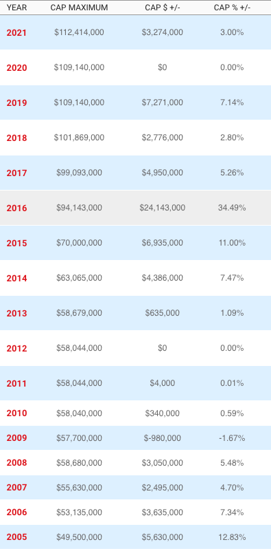

```python
Image(filename='Images/salarycap.png')
```

Image source: spotrac

Being a team sport, the overall success of a team results from the sum of every player’s contribution to the overall performance of the team. However, unlike in many other professions, the performance of NBA players is highly monitored and can hence be analysed. It is hard to gauge how much a single McDonald's employee contributes to the overall success of the restaurant as most of his actions are not quantified (an exact record of burgers made or tables wiped does not exist), or quantifiable (smiling to a client or helping a struggling colleague for instance). In basketball however, stats are plentiful and they can be used to quantify the exact contribution of every player on a given team. The idea behind our salary analysis is hence to reveal the principal determinants of salary and unveil the potential biases or discriminations hidden in the league. To do so, we will analyse and correlate player performance, experience, nationality and position with their salaries. Furthermore, we will execute a time series analysis from 2007 to 2017 in order to comprehend the evolution of player salaries and its distribution across time.

## 1.2 Literature review

As Michael Lewis explained in the movie Moneyball, “People in both fields operate with beliefs and biases. To the extent you can eliminate both and replace them with data, you gain a clear advantage.” Whether in industry or in sports, rigorous data analysis has become indispensable to inform decisions in high performing organisations. It is hence not surprising that the biggest basketball league became a subject of study for data scientists around the world. In his essay titled “Modelling the labour markets of the NBA”, Deepan Modi uses the Markowitz Model to analyse the allocation of salary in the NBA. This method enables him to measure a player’s value relative to his teammates and helps to identify underpaid prospects. On average, he found that 5.4 players are underpaid in every NBA team. The leading cause of this misalignment is hypothesised to be the artificial constraints imposed by the salary cap on the labour market. Then, Tyler Matthew Stanek in his paper “Player Performance and Team Revenues: NBA Player Salary Analysis” found that, judging by player performance, veterans were generally overpaid at the expense of young players. Once again, it is hypothesised that NBA rules such as the “veterans minimum” is responsible for the visible distortion in the labour market. Furthermore, Stanek finds that general managers put an overemphasis on points scored when analysing player performance. This shows the embedded biases of managers when distributing salaries within teams.

## 2 The Data

### 2.1 Introducing the data

For this project, we will be using data from the most complete online statistique library in American Sports: Stathead Basketball. This website records thousands of box score statistiques on historical basketball games and players from the NBA. Unfortunately, no API existed for the data we were interested in. We chose to focus our analysis on the 2016-17 season, as it is the latest season that was neither riddled with scandals nor affected by the COVID-19 pandemic. Later, we webscrapped 10 additional seasons to perform a time series analysis from 2007 to 2017.

### 2.2 Obtaining the data

For our analysis, we started by web scraping the box score of every player in the 2016-17 season. This table was composed of 486 players and 29 columns containing various information on them. From this table, we kept 5 variables containing their name, team, position, age and the link to their individual player page. Using an iteration process, we then web scraped each of the individual player pages with the links collected, and collected more personal information including their salary (for 2017), experience (years in the league), and Player Efficiency Rating (PER). After some cleaning, we merged this data into a single data frame containing 484 players and 9 variables. Two players, Tim Quarterman and Kyle Wiltjer, were dropped as no salary information was available for them.

```python
'''Code chunks in docstrings will take a long time to run.
We exported the output of all webscraping done as a CSV file (see below) that could be imported directly instead.
Code not in docstring will be needed in subsequent code chunks, hence recommended to run.'''
```

```python
"""## Extracting NBA players from season 2016-17

all_links = []
URL = "https://www.basketball-reference.com/leagues/NBA_2017_totals.html"
page = requests.get(URL)
soup = BeautifulSoup(page.content, "html.parser")
for a_href in soup.find_all("a", href=True):
    l = a_href["href"]
    all_links.append(l)

links = []
links_players = [i for i in all_links if i.startswith('/players')]
for row in links_players:
    link = "https://www.basketball-reference.com"+row
    links.append(link)

# Remove irrelevant links
for row in links:
    if len(row) <= 45:
        links.remove(row)

# Remove duplicates
links2017 = []
for row in links:
    if row not in links2017:
        links2017.append(row)

# Remove extra links picked up at the end of page
links2017 = links2017[:486]"""
```

```python
"""## Extracting basic statistics of players

# Years of experience
years = []
for URL in links2017:
    page = requests.get(URL)
    soup = BeautifulSoup(page.content, "html.parser")
    basic = soup.find('div', itemtype="https://schema.org/Person")
    p = basic.find_all('p')
    exp = p[-1]
    exp = exp.text
    exp = re.findall('\d+', exp)
    years.append(exp[0])

# Age
age = []
for URL in links2017:
    page = requests.get(URL)
    soup = BeautifulSoup(page.content, "html.parser")
    birthyear = soup.find('span', itemprop="birthDate")
    birthyear = birthyear.text
    birthyear = re.findall('\d+', birthyear)[1]
    birthyear = int(birthyear)
    a = 2017 - birthyear
    age.append(a)

# Birthplace
birthplace = []
for URL in links2017:
    page = requests.get(URL)
    soup = BeautifulSoup(page.content, "html.parser")
    bp = soup.find('span', itemprop="birthPlace")
    bp = bp.text
    bp = bp.split(',')[-1]
    bp = bp[1:]
    birthplace.append(bp)

# PER
perfstat = []
for URL in links2017:
    page = requests.get(URL)
    soup = BeautifulSoup(page.content, "html.parser")
    tr2017 = soup.find('tr', id='advanced.2017')
    td = tr2017.find_all('td')
    perf = td[6]
    perf = perf.text
    perfstat.append(perf)"""
```

```python
## Extracting season specific data of players

url = "https://www.basketball-reference.com/leagues/NBA_2017_totals.html"
html = urlopen(url)
soup = BeautifulSoup(html)
soup.findAll('tr', limit=2)
headers = [th.getText() for th in soup.findAll('tr', limit=2)[0].findAll('th')]
headers = headers[1:]
rows = soup.findAll('tr')[1:]
player_stats = [[td.getText() for td in rows[i].findAll('td')]
                    for i in range(len(rows))]
stats = pd.DataFrame(player_stats, columns = headers)
```

```python
"""
# Indexing data to allow the combining of lists
names = []
URL = "https://www.basketball-reference.com/leagues/NBA_2017_totals.html"
page = requests.get(URL)
soup = BeautifulSoup(page.content, "html.parser")
for a_href in soup.find_all("a", href=True):
    l = a_href["href"]
    if l.startswith('/players'):
        link = "https://www.basketball-reference.com"+l
        if len(link) > 45:
            n = a_href.text
            names.append(n)
names2017 = []
for n in names:
    if n not in names2017:
        names2017.append(n)
names2017 = names2017[:486]

indices = []
'''
for n in names2017:
    ind = list(stats['Player']).index(n)
    indices.append(ind)
display(indices)
On the first try, returns error that 'Paul Pierce' is not in the list.
Upon observation, Paul Pierce appears in table as 'Paul Pierce*'.
There is a need to remove * from Paul Pierce.
'''
stats['Player'] = stats['Player'].replace(['Paul Pierce*'], 'Paul Pierce')
for n in names2017:
    ind = list(stats['Player']).index(n)
    indices.append(ind)

# Position
pos = stats[stats.columns[1]][indices]

# Team
team = stats[stats.columns[3]][indices]

# Salary
salary = []
for URL in links2017:
    if URL == 'https://www.basketball-reference.com/players/w/wiltjky01.html':
        salary.append(0)
    else:
        page = requests.get(URL)
        soup = BeautifulSoup(page.content, "html.parser")

        salary_string = soup.find('div', id='all_all_salaries').find(string=lambda text: isinstance(text, Comment))
        salary_soup = BeautifulSoup(salary_string)
        salary_table = salary_soup.find('table')
        salary_tr = salary_table.find_all('tr')

        df = pd.read_html(str(salary_table))[0].fillna(0)
        filtered = df[df['Season'] == '2016-17']
        if filtered.shape[0] > 0:
            salary_player = int(filtered.iloc[0]['Salary'][1:].replace(',', ''))
        else:
            salary_player = 0
        salary.append(salary_player)"""
```

```python
"""## Combining data into a dataframe

stats2017 = pd.DataFrame(
    {'Name': names2017,
     'Page': links2017,
     'Birthplace': birthplace,
     'Years of experience': years,
     'Age': age,
     'Position': pos,
     'Team': team,
     'PER': perfstat,
     'Salary': salary})

# Cleaning dataframe
invalidstats2017 = stats2017[stats2017['Salary']==0]
display(invalidstats2017)
'''There are no salary data for Tim Quarterman and Kyle Wiltjer.'''
filteredstats2017 = stats2017[stats2017['Salary']!=0]
filteredstats2017.reset_index(drop=True, inplace=True)

# Exporting dataframe
filteredstats2017.to_csv('basicstats2017.csv')"""
```

### 2.3 Overview of NBA players' salaries

```python
# Importing webscraped data set
data = pd.read_csv("Datasets/basicstats2017.csv")
```

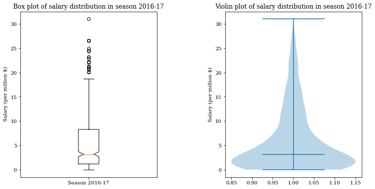

```python
fig, (ax1, ax2) = plt.subplots(1, 2, figsize=(12,6))
plt.subplots_adjust(wspace=0.5)

# box plot of salary
ax1.boxplot(data['Salary'].apply(lambda x: x / 1000000), notch=True);
ax1.set_ylabel(' Salary (per million $)')
ax1.set_xticklabels(['Season 2016-17'])
ax1.set_title("Box plot of salary distribution in season 2016-17", fontsize=12)

# violin plot of salary
ax2.violinplot(data['Salary'].apply(lambda x: x / 1000000), points=100, widths=0.3, showextrema=True, showmedians=True)
ax2.set_ylabel('Salary (per million $)')
ax2.set_title("Violin plot of salary distribution in season 2016-17", fontsize=12)

plt.show()
```

```
The gini coefficient is: 0.5461386004001111
```

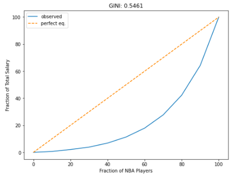

```python
## Obtaining gini-coefficient of salaries

x = data['Salary']
x = x.values.tolist()
v = np.array(x)

def G(v):
    bins = np.linspace(0, 100, 11)
    total = float(np.sum(v))
    yvals = []
    for b in bins:
        bin_vals = v[v <= np.percentile(v, b)]
        bin_fraction = (np.sum(bin_vals) / total) * 100.0
        yvals.append(bin_fraction)
    # Perfect equality area
    pe_area = np.trapz(bins, x=bins)
    # Lorenz area
    lorenz_area = np.trapz(yvals, x=bins)
    gini_val = (pe_area - lorenz_area) / float(pe_area)
    return bins, yvals, gini_val
gini = G(v)
gini = gini[-1]
print("The gini coefficient is: " + str(gini))

Image(filename='Images/gini.png')
```

## 3 What affects salary?

### 3.1 Performance and experience

To uncover the reason behind such an unequal distribution of salaries, we wondered if salaries are a good indicator of how experienced and performant NBA players are. The hypothesis is that the more experienced and performant a player is, the more valuable he is to his team and hence the higher salary he can expect to receive.

To evaluate the performance of NBA players fairly, we decided to use performance efficiency ratings. In John Hollinger’s (inventor of the PER) own words, "The PER sums up all a player's positive accomplishments, subtracts the negative accomplishments, and returns a per-minute rating of a player's performance".

For more information on the formula for calculating PER, please visit: https://www.basketball-reference.com/about/per.html.

```python
# Grouping years of experience
def categorize_exp(exp):
    if exp <= 3:
        exp_group = '01-03'
    elif exp <= 6:
        exp_group = '04-06'
    elif exp <= 9:
        exp_group = '07-09'
    elif exp <= 10:
        exp_group = '10-12'
    elif exp <= 15:
        exp_group = '13-15'
    elif exp <= 18:
        exp_group = '16-18'
    else:
        exp_group = '19-22'
    return exp_group

# Scatterplot of PER against salary, coloured by experience
data['Experience (in years)'] = data['Years of experience'].apply(lambda y: categorize_exp(y))
data_s = data.sort_values(by=['Experience (in years)'])
fig = px.scatter(data_s, x="PER", y="Salary", color="Experience (in years)", hover_data=['Name'],
                color_discrete_sequence=px.colors.sequential.Viridis_r,
                labels=dict(PER="Player Efficiency Rating (PER)", Salary="Salary (per million $)"),
                title="Relationship of PER against salary, grouped by years of experience")
#fig.write_html("1scatterplot_perf_exp.html")

'''View interactive plot via HTML file in repository'''
```

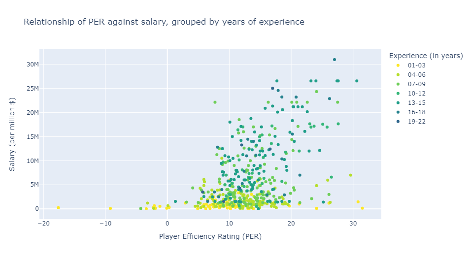

```python
Image(filename='Images/1scatterplot_perf_exp.png')
```

In this scatter plot (interactive version included as HTML file: ‘1scatterplot_perf_exp.html’), we can clearly see a correlation between performance and salary as well as between experience and salary. This comforts our hypothesis that the NBA rewards performance and experience.

There are also several extremely highly paid players observed, such as Lebron James, Russell Westbrook, Kevin Durant and James Harden located at the top right corner of the graph. Lebron James was the season’s highest earning player (close to \$31mil), though not the best performing. Westbrook is the season’s best performing (PER=30.6) and crowned the most valuable player, yet earned almost \\$5 million less. Clearly, there are other factors at play here, not all of which we can determine from the scatterplot. For one, experience could play a role as James accumulated a few more years of experience on the court than his peers.

Also, it is interesting to note that most of the players with high PER and low salary also have low experience. This might be explained by two factors. The first could be that these players signed short contracts and were not good enough to earn a real spot in a team’s roster. Their high PER would hence only be a fluke resulting from a small sample size. Alternatively, the salary limits put on “rookie contracts” signed by young players could explain why some players are underpaid. New players do not choose which team they join and hence have little bargaining power. Furthermore, the league strictly limits rookie contracts (salaries cannot exceed a % of the total salary cap of a franchise) which explains why some players like the 2021 MVP (Most Valuable Player) Nikola Jokic was so severely underpaid in 2017.

### 3.2 Do positions matter?

Next, we wondered if the roles played by NBA players on the court had an influence on their salaries.

The game of basketball is played with 10 players on the court. Naturally, this implies that each team relies on 5 players to rebound, pass, block, steal or score the ball. Like in the military, every player has a different role to play in order to make the team as efficient and performant as possible.

The roles are divided as follows:

- Point Guard (The general): He is responsible for running the plays, organising the offence and making good passes. He is often smaller than his teammates but is an excellent dribbler.
- Center (The tank): He is often the tallest player on the team, plays close to the basket and tries to get as many offensive and defensive rebounds as possible. On defence he is responsible for guarding the basket and blocking incoming shots.
- Shooting Guard (The sniper): He is the team’s best shooter and can shoot the ball from behind the 3 point line. He is also a good dribbler and can create plays as well.
- Small Forward (The Swiss knife): He can defend against all opposing players as well as score from close and long distance.
- Power Forward (Support): His role is similar to the centers although he can shoot from further and is often more mobile.

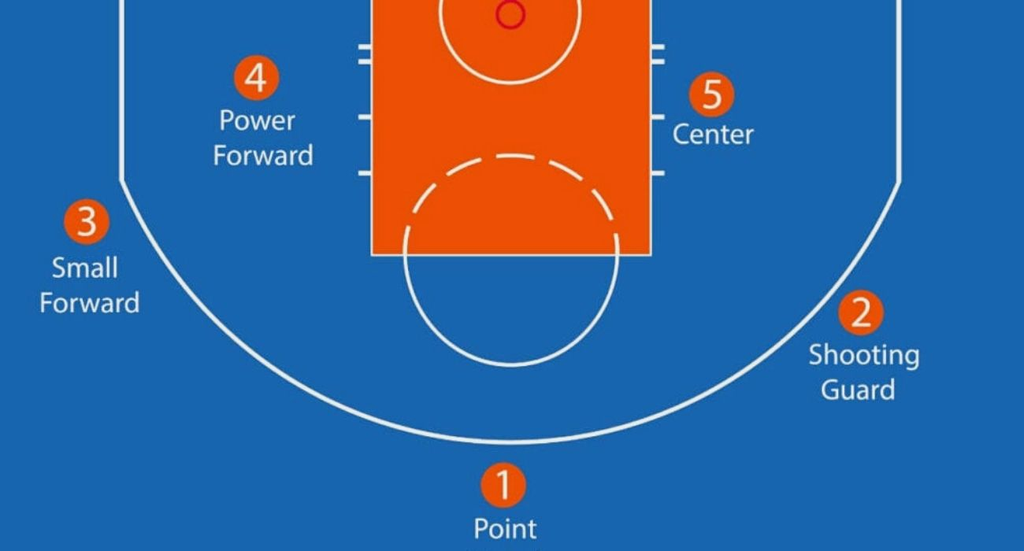

```python
Image(filename='Images/bball_pos.jpeg')
```

Image source: Chase Your Sport

```python
# Cleaning position data
for i in range(len(data)):
    if data['Position'][i]=='PF-C':
        data.loc[i,'Position']='PF'

# Scatterplot of PER against salary, coloured by positions
fig = px.scatter(data, x="PER", y="Salary", color="Position", hover_data=['Name'],
                labels=dict(PER="Player Efficiency Rating (PER)", Salary="Salary (per million $)"),
                title="Relationship of PER against salary, grouped by positions on court")
#fig.write_html("2scatterplot_perf_pos.html")

'''View interactive plot via HTML file in repository'''
```

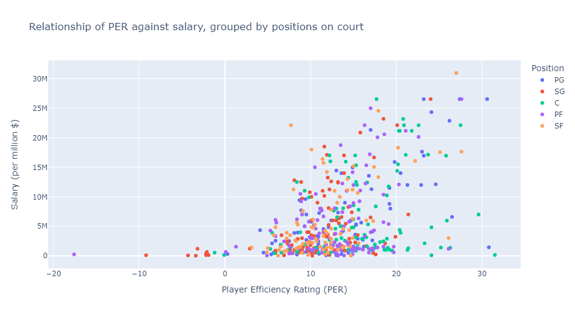

```python
Image(filename='Images/2scatterplot_perf_pos.png')
```

```python
## Extracting specific performance statistics of each position

PG = stats.loc[stats['Pos'] == 'PG']
SG = stats.loc[stats['Pos'] == 'SG']
C = stats.loc[stats['Pos'] == 'C']
SF = stats.loc[stats['Pos'] == 'SF']
PF = stats.loc[stats['Pos'] == 'PF']

def avg(lst):
    return sum(lst) / len(lst)

# Performance statistics for PG
# Sum of points
PTS_PG = PG["PTS"]
PTS_PG = PTS_PG.values.tolist()
PTS_PG_list = []
for x in PTS_PG:
    pts = int(x)
    PTS_PG_list.append(pts)
PTS_PG_sum = sum(PTS_PG_list)

# Sum of games played
G_PG = PG["G"]
G_PG = G_PG.values.tolist()
G_PG_list = []
for x in G_PG:
    pts = int(x)
    G_PG_list.append(pts)
G_PG_sum = sum(G_PG_list)
G_PG_avg = sum(G_PG_list)/len(G_PG_list)

# Average points scored in a game
PTS_PG = PTS_PG_sum/G_PG_sum

# Sum of rebounds
TRB_PG = PG["TRB"]
TRB_PG = TRB_PG.values.tolist()
TRB_PG_list = []
for x in TRB_PG:
    trb = int(x)
    TRB_PG_list.append(trb)
TRB_PG_sum = sum(TRB_PG_list)
TRB_PG = TRB_PG_sum/G_PG_sum

# Sum of assists
AST_PG = PG['AST']
AST_PG = AST_PG.values.tolist()
AST_PG_list = []
for x in AST_PG:
    ast = int(x)
    AST_PG_list.append(ast)
AST_PG_sum = sum(AST_PG_list)
AST_PG = AST_PG_sum/G_PG_sum

# Sum of steals
STL_PG = PG['STL']
STL_PG = STL_PG.values.tolist()
STL_PG_list = []
for x in STL_PG:
    stl = int(x)
    STL_PG_list.append(stl)
STL_PG_sum = sum(STL_PG_list)
STL_PG = STL_PG_sum/G_PG_sum

# Sum of blocks
BLK_PG = PG['BLK']
BLK_PG = BLK_PG.values.tolist()
BLK_PG_list = []
for x in BLK_PG:
    blk = int(x)
    BLK_PG_list.append(blk)
BLK_PG_sum = sum(BLK_PG_list)
BLK_PG = BLK_PG_sum/G_PG_sum

'''The same steps are repeated for the other 4 positions. For the readability of this report, we have excluded the code.
Instead, we exported the scraped and manipulated data into a dataframe in the form of a CSV file.
We will import this in the next code chunk for subsequent analysis.'''
```

```python
# Importing web scraped and manipulated performance statistics
dfsummary = pd.read_csv("Datasets/pos_perfstat.csv")
print(dfsummary)
```

```
  Position        PTS       AST       TRB       STL       BLK
0       SG  10.202998  1.979017  2.698585  0.732223  0.236969
1       SF   9.746624  1.687633  3.833511  0.824094  0.368692
2       PF   8.810251  1.329769  4.703836  0.583842  0.525628
3        C   9.500797  1.364570  6.340833  0.595748  0.905049
4       PG  10.834857  4.149363  2.737314  0.852788  0.191859
```

```python
# Creating radar plot
theta=['Points','Assists','Rebounds','Steals', 'Blocks']
theta = [*theta, theta[0]]
r1=[PTS_C, AST_C, TRB_C, STL_C, BLK_C]
r1 = [*r1, r1[0]]
r2=[PTS_PF, AST_PF, TRB_PF, STL_PF, BLK_PF]
r2 = [*r2, r2[0]]
r3=[PTS_SF, AST_SF, TRB_SF, STL_SF, BLK_SF]
r3 = [*r3, r3[0]]
r4=[PTS_SG, AST_SG, TRB_SG, STL_SG, BLK_SG]
r4 = [*r4, r4[0]]
r5=[PTS_PG, AST_PG, TRB_PG, STL_PG, BLK_PG]
r5 = [*r5, r5[0]]

fig = go.Figure(
    data=[
        go.Scatterpolar(r=r1, theta=theta, name='Center'),
        go.Scatterpolar(r=r2, theta=theta, name='Power Forward'),
        go.Scatterpolar(r=r3, theta=theta, name='Small Forward'),
        go.Scatterpolar(r=r4, theta=theta, name='Shooting Guard'),
        go.Scatterpolar(r=r5, theta=theta, name='Point Guard')],
    layout=go.Layout(
        title=go.layout.Title(text='Performance Statistics by Position'),
        polar={'radialaxis': {'visible': True}},
        showlegend=True))

#fig.write_html("3radarplot_perf_pos.html")

'''View interactive plot via HTML file in repository'''
```

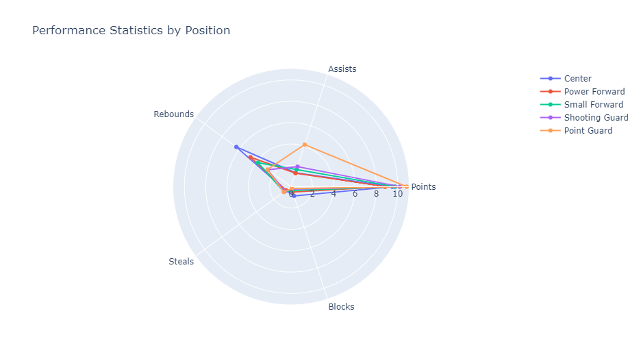

```python
Image(filename='Images/3radarplot_perf_pos.png')
```

Naturally, different positions entail different responsibilities. Thus, it is not surprising to observe players with very different statistics. We have included a summary table of performance statistics of the different positions. A radar chart is plotted (interactive version included as HTML file: ‘3radarplot_perf_pos.html’) to enable us to visualise the five key statistics (points scored, rebounds, steals, blocks and passes leading to a basket) on the same scale. Positions can be selected and unselected by the legend to allow for comparison without crowding the plot. In general, the more area the plot takes up, the better the PER. Immediately, we can see that point guards scored way more assists compared to other positions, due to the very nature of their role on the court. They also scored slightly more points than others, but fell very flat in terms of rebounds. This could thus potentially even out their PER scores. It seems true, though, that centres score higher PER as their higher number of rebounds and blocks give them a slight edge on other positions. While it is difficult to conclude that one position always obtains a higher PER score, this plot shows that there could be a potential correlation between position and PER, which could thus become a confounding factor in salary determination.

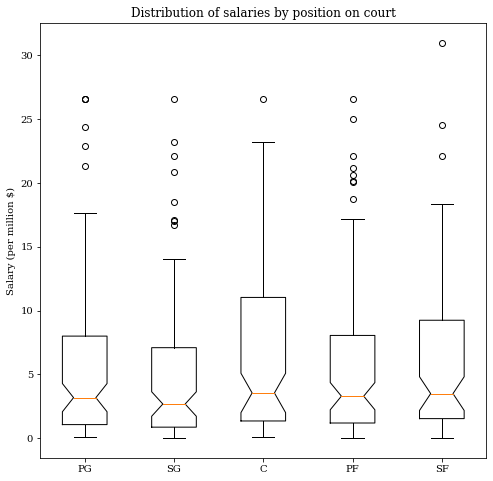

```python
# Box plots of salaries by position
pos={}
for p in data['Position']:
    pos[p]=data[data['Position']==p]['Salary'].apply(lambda x: x / 1000000)

fig, ax = plt.subplots(figsize=(8, 8))
ax.boxplot(pos.values(), notch=True)
ax.set_ylabel('Salary (per million $)')
ax.set_xticklabels(pos.keys())
ax.set_title("Distribution of salaries by position on court")

plt.show()
```

We then turn to the distribution of salaries by position. It appears that players' salaries vary very differently from position to position. Shooting guards appear to have a smaller salary range as compared to centres, though all positions have outliers who earn an extremely high salary relative to their peers playing the same position. However, as we fail to establish a correlation between salary and positions in our analysis above, it is difficult to comment on the inequality of salary between different positions. It could just be coincidental that centres experience a more unequal salary distribution compared to the rest of the league. If we had used a sample from a different season, we could have obtained a different distribution pattern.

### 3.3 Domestic vs Foreign: Is there discrimination or favouritism?

```python
## Cleaning nationality data
us_states = ['Alabama','Alaska','Arizona','Arkansas','California','Colorado','Connecticut','Delaware','Florida',\
             'Georgia','Hawaii','Idaho','Illinois','Indiana','Iowa','Kansas','Kentucky','Louisiana','Maine',\
             'Maryland','Massachusetts','Michigan','Minnesota','Mississippi','Missouri','Montana','Nebraska',\
             'Nevada','New Hampshire','New Jersey','New Mexico','New York','North Carolina','North Dakota','Ohio',\
             'Oklahoma','Oregon','Pennsylvania','Rhode Island','South Carolina','South Dakota','Tennessee',\
             'Texas','Utah','Vermont','Virginia','Washington','West Virginia','Wisconsin','Wyoming']

# Cleaning birthplace column
data.loc[46,'Birthplace'] = 'Ghana'
data['Birthplace'] = data['Birthplace'].replace(['District of Columbia'],'Washington')

# Adding country column
data['Country'] = data['Birthplace']
for i in range(len(data['Birthplace'])):
    if data['Birthplace'][i] in us_states:
        data.loc[i,'Country'] = 'United States'

# Cleaning country column
'''Al-Farouq Aminu and Zaza Pachulia are players from the country Georgia and not the US State Georgia'''
data.loc[13,'Country'] = 'Georgia'
data.loc[345,'Country'] = 'Georgia'
```

```python
## Summary of domestic vs foreign players' salaries
domestic = data[data['Country']=='United States']
foreign = data[data['Country']!='United States']
dom_sum = domestic['Salary'].describe().apply(lambda x: format(x, 'f'))
for_sum = foreign['Salary'].describe().apply(lambda x: format(x, 'f'))
print('Domestic:')
print(dom_sum)
print('\nForeign:')
print(for_sum)
```

```
Domestic:
count         368.000000
mean      5818668.111413
std       6525569.215485
min         23069.000000
25%       1051996.750000
50%       2989125.000000
75%       8128438.000000
max      30963450.000000
Name: Salary, dtype: object

Foreign:
count         116.000000
mean      6006592.724138
std       6015503.743977
min         51449.000000
25%       1679700.000000
50%       3548074.000000
75%       8381250.000000
max      26540100.000000
Name: Salary, dtype: object
```

From the printed summary statistics, it seems that domestic players are paid less than foreign players; the mean annual salary of domestic players is less than that of foreign players by approximately \$200k. This could be misled by outliers however, as salaries paid out to domestic players vary and are more extreme than foreign players - the minimum salary recorded for domestic players (\\$23k) is way less than that of the foreign players (\$50k) while the highest recorded salary for domestic players (\\$31mil) is way higher than that of the foreign players (\$26.5mil). We thus generated box plots displaying the salary distribution of domestic and foreign players to paint a more accurate visual picture.

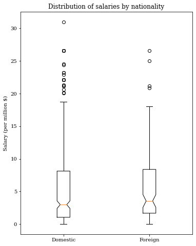

```python
## Comparing distribution of salaries between domestic and foreign players
combined = {'Domestic': domestic['Salary'].apply(lambda x: x / 1000000),\
            'Foreign': foreign['Salary'].apply(lambda x: x / 1000000)}
fig, ax = plt.subplots(figsize=(6, 8))
ax.boxplot(combined.values(), notch=True)
ax.set_ylabel('Salary (per million $)')
ax.set_xticklabels(combined.keys())
ax.set_title("Distribution of salaries by nationality")
plt.show()
```

Here, the distributions of salary do not appear to be too different. The median salary of foreign players is slightly higher than that of domestic players and the range of salary is smaller as well. The 25-75 percentiles of foreign players earn slightly more than the domestic players and there are fewer outliers. There are, on the other hand, many high-earning American players with extreme salaries - domestic salaries seem to fluctuate more and display more inequality than foreign players.

To further inform our analysis, we decided to look at the foreign players in greater detail. Embedding spatial coordinates to the players’ birthplace data, we mapped the home countries of NBA players. The scale of the map and its bubble plots are interactive and inform us of the number of players recorded in each country.

```python
## Preparing data for spatial analysis

# Adding lat/long data for countries
latlong_countries = pd.read_csv('Datasets/average-latitude-longitude-countries.csv')
latlong_countries.loc[latlong_countries.shape[0]]=['SSD','South Sudan',6.87,31.30]
latlong_countries['Country'] = latlong_countries['Country'].replace(['Congo, The Democratic Republic of the'],\
                                                                  'Democratic Republic of the Congo')
latlong_countries['Country'] = latlong_countries['Country'].replace(['Congo'],\
                                                                  'Republic of the Congo')
latlong_countries['Country'] = latlong_countries['Country'].replace(['Russian Federation'],\
                                                                  'Russia')
data['lat'] = 0
data['long'] = 0
for i in range(len(data['Country'])):
    l=latlong_countries.index[latlong_countries['Country']==data.loc[i,'Country']].tolist()[0]
    data.loc[i,'lat'] = latlong_countries.loc[l,'Latitude']
    data.loc[i,'long'] = latlong_countries.loc[l,'Longitude']

# Adding lat/long data for US states
latlong_usstates = pd.read_csv('Datasets/us-state-capitals.csv')
data['lat_us'] = 0
data['long_us'] = 0
for i in range(len(data['Birthplace'])):
    if data['Birthplace'][i] in us_states:
        l=latlong_usstates.index[latlong_usstates['name']==data.loc[i,'Birthplace']].tolist()[0]
        data.loc[i,'lat_us'] = latlong_usstates.loc[l,'latitude']
        data.loc[i,'long_us'] = latlong_usstates.loc[l,'longitude']
    else:
        data.loc[i,'lat_us'] = data.loc[i,'lat']
        data.loc[i,'long_us'] = data.loc[i,'long']
```

```python
'''Run this to run the code for the interactive maps'''
#conda install -c conda-forge folium
```

```python
## Interactive world map

m_world = folium.Map(location=[20,0], tiles="OpenStreetMap", zoom_start=2)

# Counting players by country
data.groupby(["Country","Birthplace"]).count()

countries = []
for i in range(len(data)):
    if data.iloc[i]['Country'] not in countries:
        countries.append(data.iloc[i]['Country'])

lat_countries = []
long_countries = []
nplayers = []
for c in countries:
    li=latlong_countries.index[latlong_countries['Country']==c].tolist()[0]
    lat=latlong_countries.loc[li,'Latitude']
    lat_countries.append(lat)
    long=latlong_countries.loc[li,'Longitude']
    long_countries.append(long)

    c1 = c.replace(" ","")
    c1 = data[data['Country']==c]
    n = len(c1)
    nplayers.append(n)

nationality = pd.DataFrame(
    {'Country': countries,
     'No. of Players': nplayers,
     'Latitude': lat_countries,
     'Longitude': long_countries})

# Creating bubble map
for i in range(len(nationality)):
   folium.Circle(
      location=[nationality.iloc[i]['Latitude'], nationality.iloc[i]['Longitude']],
      popup=nationality.iloc[i]['Country'] + ': ' + str(nationality.iloc[i]['No. of Players']),
      radius=float(nationality.iloc[i]['No. of Players'])*15000,
      color='blue',
      fill=True,
      fill_color='blue'
   ).add_to(m_world)
m_world
```

Make this Notebook Trusted to load map: File -> Trust Notebook

[interactive chart not shown]

The US returns the biggest bubble of course, followed by Canada, France, Brazil and Spain. NBA players can be found quite literally all over the world, with the exception of Asia. Most foreign players come from the American continents, Western Europe and Sub-Saharan Africa.

```python
## Interactive US Map

m_us = folium.Map(location=[37.0902,-95.7129], tiles="OpenStreetMap", zoom_start=4)

# counting players by state
us_states_filtered = ['Alabama','Arizona','Arkansas','California','Colorado','Connecticut','Delaware','Florida',\
                      'Georgia','Illinois','Indiana','Iowa','Kansas','Kentucky','Louisiana','Maryland','Massachusetts',\
                      'Michigan','Minnesota','Mississippi','Missouri','Nevada','New Hampshire','New Jersey',\
                      'New Mexico','New York','North Carolina','North Dakota','Ohio','Oklahoma','Oregon',\
                      'Pennsylvania','South Carolina','South Dakota','Tennessee','Texas','Utah','Virginia',\
                      'Washington','West Virginia','Wisconsin','Wyoming']
lat_states = []
long_states = []
nplayers_states = []
for u in us_states_filtered:
    li1=latlong_usstates.index[latlong_usstates['name']==u].tolist()[0]
    lat1=latlong_usstates.loc[li1,'latitude']
    lat_states.append(lat1)
    long1=latlong_usstates.loc[li1,'longitude']
    long_states.append(long1)

    u1 = u.replace(" ","")
    u1 = data[data['Birthplace']==u]
    n1 = len(u1)
    nplayers_states.append(n1)

nationality_us = pd.DataFrame(
    {'US State': us_states_filtered,
     'No. of Players': nplayers_states,
     'Latitude': lat_states,
     'Longitude': long_states})

# Creating bubble map
for i in range(len(nationality_us)):
   folium.Circle(
      location=[nationality_us.iloc[i]['Latitude'], nationality_us.iloc[i]['Longitude']],
      popup=nationality_us.iloc[i]['US State'] + ': ' + str(nationality_us.iloc[i]['No. of Players']),
      radius=float(nationality_us.iloc[i]['No. of Players'])*13000,
      color='crimson',
      fill=True,
      fill_color='crimson'
   ).add_to(m_us)
m_us
```

Make this Notebook Trusted to load map: File -> Trust Notebook

[interactive chart not shown]

Given the huge proportion of US players, we decided to visualise the spatial distribution of US players as well. We notice spatial clustering around the coasts and very few NBA players come from the mid section of the US. Players are relatively evenly distributed otherwise, with most states fetching similar numbers of players, with the exception of California. This could be misleading however, as population is not taken into account and a densely populated state like California will most definitely produce more players than a less dense state like New Mexico although they are almost equal in land mass. To correct for this, one could calculate the ratio of NBA players per million inhabitants.

To transform the spatial data and identify patterns in salary distribution, we categorised the countries where NBA players come from into major regions: US, Canada, South America, Europe, Middle East, Africa and Oceania. We then set out to find out where the top and bottom 30% of salary distribution go to.

```python
## Analysing salary by region

# Grouping players by region
souamer = ['Bahamas','Haiti','Dominican Republic','Puerto Rico','Venezuela','French Guiana','Brazil','Argentina']
eur = ['Sweden','Spain','France','Germany','Belgium','Switzerland','Italy','Austria','Slovenia','Czech Republic','Poland',\
      'Croatia','Bosnia and Herzegovina','Serbia','Montenegro','Greece','Lithuania','Latvia','Ukraine','Russia']
mideast = ['Turkey','Georgia','Israel']
afr = ['Tunisia','Mali','Cape Verde','Senegal','Ghana','Cameroon','South Sudan',\
       'Republic of the Congo','Democratic Republic of the Congo']
oce = ['Australia','New Zealand']

data['Region'] = 0
for i in range(len(data)):
    if data['Country'][i]=='United States':
        data.loc[i,'Region'] = 'United States'
    if data['Country'][i]=='Canada':
        data.loc[i,'Region'] = 'Canada'
    if data['Country'][i] in souamer:
        data.loc[i,'Region'] = 'South America'
    if data['Country'][i] in eur:
        data.loc[i,'Region'] = 'Europe'
    if data['Country'][i] in mideast:
        data.loc[i,'Region'] = 'Middle East'
    if data['Country'][i] in afr:
        data.loc[i,'Region'] = 'Africa'
    if data['Country'][i] in oce:
        data.loc[i,'Region'] = 'Oceania'
```

```python
'''Run this to run the code for the sankey diagram'''
#pip install pysankey
```

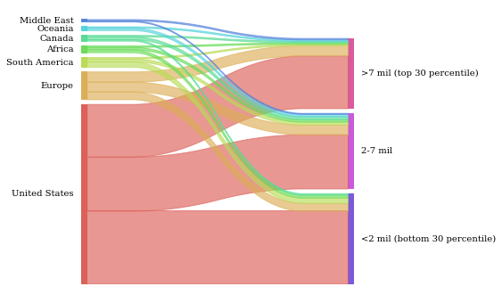

```python
## Creating sankey diagram

# Figuring out salary bins
data['Salary'].quantile(0.3)
data['Salary'].quantile(0.7)

# Grouping players' salaries
data['Salary Range'] = 0
for i in range(len(data)):
    if data['Salary'][i] < 2000000:
        data.loc[i,'Salary Range'] = '<2 mil (bottom 30 percentile)'
    if data['Salary'][i] >= 2000000 and data['Salary'][i] < 7000000:
        data.loc[i,'Salary Range'] = '2-7 mil'
    if data['Salary'][i] >= 7000000:
        data.loc[i,'Salary Range'] = '>7 mil (top 30 percentile)'

data_s = data.sort_values(by=['Salary'])
sankey(data_s['Region'], data_s['Salary Range'], aspect=20, fontsize=10)
```

The sankey diagram above shows the flow of salary by region. We first found out what the 30th and 70th percentile of salary was (\$2mil and \\$7mil respectively), then split the NBA players’ salaries into three bins: the bottom 30 percentile, the 30-70th percentile (average) and the top 30 percentile. There is no obvious bias in salary distribution with the given regions of the world. However, some observations can be made. Firstly, it is no surprise that the US players dominate all three bins as they make up the biggest group, but it is worth noting that the US players take up a bigger proportion in the bottom 30 percentile bin than they do in the other two. European players are slightly more likely to end up in the higher salary bins, as do players from the Middle East and Oceania, though the latter could be inaccurate due to the small sample size. Most of the South American players, on the other hand, end up in the lower salary bins. The small sample size makes it difficult to come to conclusions - certain players could all happen to come from the same region and end up earning more simply because they have really good skills and not because of where they come from. If the same analysis is done on a bigger sample size, perhaps including smaller leagues or other seasons, more conclusive remarks could be made. Nonetheless, for the season 2016-17, it seems unlikely that there has been any discrimination or favourtism towards foreign players.

### 3.4 Do some teams pay more than others?

The next natural question one could ask is whether salaries differ from team to team. More interestingly, one can wonder what salary distributions tell us about the profile of the league’s teams.

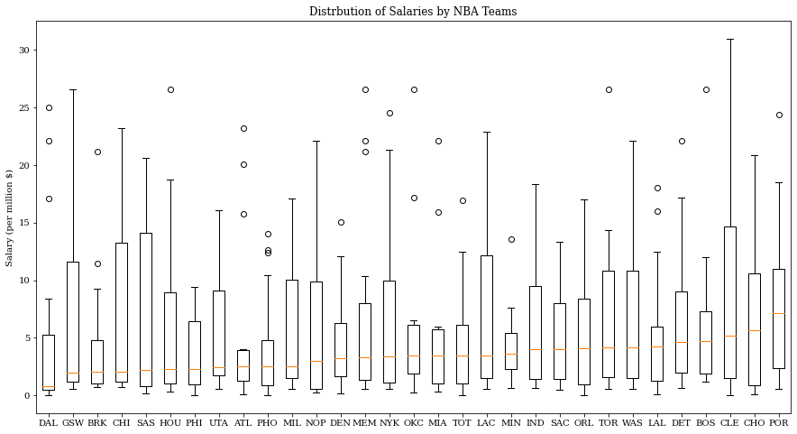

```python
## Visualising the salary distribution by team
# Sorting teams by median salary:
data['Team Salary Average'] = 0
for i in range(len(data)):
    t = data['Team'][i]
    filtered_t = data[data['Team']==t]
    t_med = filtered_t['Salary'].median()
    data.loc[i,'Team Salary Average'] = t_med
data_s = data.sort_values(by=['Team Salary Average'])

# Box plots of salary distribution by team
team={}
for t in data_s['Team']:
    team[t]=data_s[data_s['Team']==t]['Salary'].apply(lambda x: x / 1000000)

fig, ax = plt.subplots(figsize=(15,8))
ax.boxplot(team.values())
ax.set_ylabel('Salary (per million $)')
ax.set_xticklabels(team.keys())
ax.set_title("Distrbution of Salaries by NBA Teams")
plt.show()
```

As we can see from these boxplots, salary distributions vary a lot in the NBA. Some teams like Orlando, Sacramento or Indiana seem to have well distributed wages. Indeed, their median salary is centred in the box plot and their distribution is only slightly skewed. More importantly, they have no outliers. This hints to the fact that these teams are built around a cast of good players but have no superstars taking up a big share of their salary space. On the other hand, teams like the Houston Rockets, the Atlanta Hawks or the Oklahoma Thunder seem to be built around one or a couple very expensive players. Indeed, their box plots either show many outliers or a long fourth quartile whisker. Salaries can henceforth inform us on the strategy of basketball teams. Some will rely on teamwork and pay relatively equal pay to their players while others will count on their superstars and build an accompanying cast of lower paid players around them. While this graph tells us nothing of the quality of these strategies, it is interesting to note that most of them show an inclination for the latter.

## 4 Quantifying the Relationship: Regression Analysis

### 4.1 Multiple linear regression

Having visualised our chosen variables and their relationship with salary, we introduce a multiple regression model to further substantiate our findings and quantify the relationships discovered. We regress salary (dependent variable) against experience, nationality and PER score (independent variables), using positions as our control variables. Since nationality and positions are categorical variables, we created dummy variables: ‘C’, ‘PF’, ‘PG’, ‘SF’ and ‘Foreign?’ where they each take the value 1 if true and 0 otherwise).

From our previous visualisation and analysis, we expect the salary of an NBA player to increase as experience and performance increase. Using the multiple linear regression model, fitted by the Least Squares Estimation (OLS) method, we hope to confirm this correlation, as well as quantify the relationship, which could also allow for future modelling if we hope to predict a player’s salary.

```python
## Preparing data for regression analysis
# Creating dummy variables for categorical variables
data['Foreign?'] = 0
for i in range(len(data)):
    if data['Country'][i]=='United States':
        data.loc[i,'Foreign?'] = 0
    if data['Country'][i]!='United States':
        data.loc[i,'Foreign?'] = 1
df1_dummy = pd.get_dummies(data["Position"])
data = pd.concat([data, df1_dummy], axis=1)

data['Foreign?'] = data['Foreign?'].astype(float)
data['C'] = data['C'].astype(float)
data['PF'] = data['PF'].astype(float)
data['PG'] = data['PG'].astype(float)
data['SF'] = data['SF'].astype(float)
data['SG'] = data['SG'].astype(float)
```

```python
## Performing regression analysis
x = data[['Years of experience','Foreign?','PER','C','PF','PG','SF']]
y = data[['Salary']]
X = sm.add_constant(x)
model = sm.OLS(y,X)
results = model.fit()
print(results.summary())

# Suppress scientific notation
ressum = pd.DataFrame(results.params)
print("\nRegression coefficients:")
print(ressum.apply(lambda x: '%.6f' % x, axis=1))
```

```
                            OLS Regression Results
==============================================================================
Dep. Variable:                 Salary   R-squared:                       0.420
Model:                            OLS   Adj. R-squared:                  0.411
Method:                 Least Squares   F-statistic:                     49.23
Date:                Wed, 26 Jan 2022   Prob (F-statistic):           1.56e-52
Time:                        21:00:39   Log-Likelihood:                -8139.7
No. Observations:                 484   AIC:                         1.630e+04
Df Residuals:                     476   BIC:                         1.633e+04
Df Model:                           7
Covariance Type:            nonrobust
=======================================================================================
                          coef    std err          t      P>|t|      [0.025      0.975]
---------------------------------------------------------------------------------------
const               -4.442e+06   7.17e+05     -6.199      0.000   -5.85e+06   -3.03e+06
Years of experience  7.238e+05   5.61e+04     12.909      0.000    6.14e+05    8.34e+05
Foreign?             3.169e+05   5.37e+05      0.590      0.556   -7.39e+05    1.37e+06
PER                  3.601e+05   4.29e+04      8.393      0.000    2.76e+05    4.44e+05
C                   -6.026e+05   7.43e+05     -0.811      0.418   -2.06e+06    8.58e+05
PF                  -3.053e+05   6.96e+05     -0.439      0.661   -1.67e+06    1.06e+06
PG                  -6.133e+05   7.04e+05     -0.871      0.384      -2e+06     7.7e+05
SF                  -4.914e+05   7.26e+05     -0.677      0.499   -1.92e+06    9.35e+05
==============================================================================
Omnibus:                       42.695   Durbin-Watson:                   1.918
Prob(Omnibus):                  0.000   Jarque-Bera (JB):               53.080
Skew:                           0.720   Prob(JB):                     2.98e-12
Kurtosis:                       3.747   Cond. No.                         87.9
==============================================================================

Notes:
[1] Standard Errors assume that the covariance matrix of the errors is correctly specified.

Regression coefficients:
const                  -4442086.084915
Years of experience      723784.732450
Foreign?                 316876.050899
PER                      360055.999355
C                       -602573.139430
PF                      -305326.525964
PG                      -613342.669763
SF                      -491364.867778
dtype: object
```

In the summary statistics, we can easily observe the estimated regression coefficients as well as the intercept. The second output is included to suppress the scientific notation in the statistics summary. Additionally, we observe the R-squared which is 42%, which means that independent variables are “responsible” for 42% of the variation of the variable of interest that is salary. This is pretty substantial given that we have only used three explanatory variables in the model.

However, we can see that the really small p-values are those corresponding to the independent variables of experience and PER only. The corresponding correlations of these two variables with salary are statistically significant. The regression coefficient of experience is 723784.73, which actually means that an increase in one year of experience would increase the salary by \$723,784.73. In the same manner, an increase of one unit of PER would increase the salary of the player by \\$360,056.

The model outputs that the coefficient of nationality (defined as whether or not a player is foreign or not) is 316876, which would mean that on average, foreign players earned \$316,876 more than US players. However, we cannot conclude that this is always the case given that it is statistically insignificant. Instead, it could be that foreign players in our sample are paid more that season as they are inherently very skilled players who happen to be foreign. It is more plausible that NBA teams headhunt only the best players from other countries, and could be more lax with their standards for domestic players. It could also be that foreign players have a different playing style that translates to better PER statistics and hence higher salaries. There are many possibilities; we cannot however conclude that there is a correlation between salary and nationality. These findings align with our insights from our visualisation plots earlier.

### 4.2 Correlation tests

To further analyse the relationship between salary, experience and performance respectively, we introduce two well-known correlation tests, namely the Pearson’s correlation test and the Kendall’s rank correlation test. The former test is used to interpret linear relationships while the latter is used for non-linear ones.

```python
## Correlation Tests

# Pearson's correlation test (linear relationship)
# Kendall's rank correlation test (non-linear relationship)
corr, p = pearsonr(data['Salary'],data['Years of experience'])
print('Relationship between salary and experience')
print('Pearsons correlation coefficient: %.5f' % corr)
print('p-value: %.5f' % p)
corr, p = kendalltau(data['Salary'],data['Years of experience'])
print("Kendall's tau: %.5f" % corr)
print('p-value: %.5f' % p)

corr, p = pearsonr(data['Salary'],data['PER'])
print('\nRelationship between salary and performance')
print('Pearsons correlation coefficient: %.5f' % corr)
print('p-value: %.5f' % p)
corr, p = kendalltau(data['Salary'],data['PER'])
print("Kendall's tau: %.5f" % corr)
print('p-value: %.5f' % p)
```

```
Relationship between salary and experience
Pearsons correlation coefficient: 0.57201
p-value: 0.00000
Kendall's tau: 0.52294
p-value: 0.00000

Relationship between salary and performance
Pearsons correlation coefficient: 0.45866
p-value: 0.00000
Kendall's tau: 0.28261
p-value: 0.00000
```

Starting with the Pearson's correlation coefficient, we can observe that both variables are positively linearly correlated with salary, and the correlation between salary and experience is stronger (= 0.57) than the correlation between the salary and performance (=0.45). Both have very small p-values, hence we can conclude that these correlations are statistically significant. Similarly, Kendall's rank correlation test fetches positive tau values with very small p-values for both variables, implying a positive non-linear correlation with salary. This time though, Kendall’s tau value for experience (=0.52) is a lot higher than that of performance (=0.28). These outcomes signal the possibility of a non-parametric relationship between the variables which would warrant further tests and analysis. We foresee some difficulties, however, such as the limits of the data that can be collected. Experience is measured by the years of experience and basketball, as with all sports, can be age sensitive. It is difficult to find players above a certain number of years of experience simply because many of them retire due to decreased agility or simply fatigue from having played for so many years. This limits our dataset greatly, which could then hinder more accurate analysis of the relationship.

### 4.3 K-means clustering

Having quantified the relationships, we use the k-means clustering method to cluster the data into five clusters. The choice of the five clusters was made arbitrarily. We chose salary, age, experience as well as the five positions to inform our clustering algorithm. After implementing the k-means method, the algorithm assigns a number from 0 to 4 inclusive.

```python
# Creating kmeans model with 5 clusters
kmeans_model = KMeans(n_clusters=5, random_state=1)
columns = data[["Salary","C","PF","PG","SF","SG","Age","Years of experience"]]
kmeans_model.fit(columns)
labels = kmeans_model.labels_
```

After implementing the k-means method, we apply the Principle Component Analysis (PCA) to "summarise" the key information of all eight variables used, reducing the dimensionality of our data so as to synthesise two principal components.

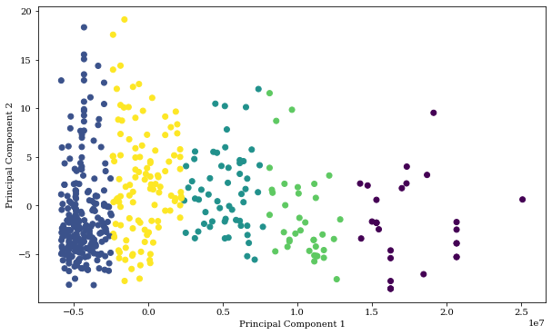

```python
# Two dimensions pattern recognition
pca_2 = PCA(2)
plot_columns = pca_2.fit_transform(columns)

fig,ax = plt.subplots(figsize=(10,6))
plt.scatter(x=plot_columns[:,0], y=plot_columns[:,1],c=labels)
plt.xlabel("Principal Component 1")
plt.ylabel("Principal Component 2")
plt.show()
```

In the above graph it is easy to distinguish the five clusters. We then look into the summary of the five clusters to recognise patterns or specific characteristics of each cluster of players.

```python
## Summary of the 5 clusters
data = data.drop(labels=['Unnamed: 0', 'lat', 'long', 'lat_us', 'long_us'], axis=1)

# Cluster 1
data.iloc[labels == 0]
data.iloc[labels == 0].describe()
```

|  | Years of experience | Age | PER | Salary | Team Salary Average | Foreign? | C | PF | PG | SF | SG |
| --- | --- | --- | --- | --- | --- | --- | --- | --- | --- | --- | --- |
| count | 28.000000 | 28.000000 | 28.000000 | 2.800000e+01 | 2.800000e+01 | 28.000000 | 28.000000 | 28.000000 | 28.000000 | 28.000000 | 28.000000 |
| mean | 13.035714 | 29.607143 | 21.160714 | 2.334589e+07 | 3.401199e+06 | 0.142857 | 0.285714 | 0.250000 | 0.214286 | 0.107143 | 0.142857 |
| std | 3.202801 | 3.370232 | 4.764634 | 2.664339e+06 | 1.411236e+06 | 0.356348 | 0.460044 | 0.440959 | 0.417855 | 0.314970 | 0.356348 |
| min | 9.000000 | 24.000000 | 7.700000 | 2.007203e+07 | 7.777865e+05 | 0.000000 | 0.000000 | 0.000000 | 0.000000 | 0.000000 | 0.000000 |
| 25% | 10.500000 | 28.000000 | 17.875000 | 2.116568e+07 | 2.452320e+06 | 0.000000 | 0.000000 | 0.000000 | 0.000000 | 0.000000 | 0.000000 |
| 50% | 13.000000 | 29.000000 | 20.850000 | 2.211675e+07 | 3.399000e+06 | 0.000000 | 0.000000 | 0.000000 | 0.000000 | 0.000000 | 0.000000 |
| 75% | 15.000000 | 32.000000 | 24.025000 | 2.538502e+07 | 4.172810e+06 | 0.000000 | 1.000000 | 0.250000 | 0.000000 | 0.000000 | 0.000000 |
| max | 21.000000 | 39.000000 | 30.600000 | 3.096345e+07 | 7.173816e+06 | 1.000000 | 1.000000 | 1.000000 | 1.000000 | 1.000000 | 1.000000 |

```python
# Cluster 2
data.iloc[labels == 1]
data.iloc[labels == 1].describe()
```

|  | Years of experience | Age | PER | Salary | Team Salary Average | Foreign? | C | PF | PG | SF | SG |
| --- | --- | --- | --- | --- | --- | --- | --- | --- | --- | --- | --- |
| count | 250.000000 | 250.000000 | 250.000000 | 2.500000e+02 | 2.500000e+02 | 250.000000 | 250.000000 | 250.000000 | 250.000000 | 250.000000 | 250.000000 |
| mean | 5.784000 | 25.748000 | 11.436400 | 1.392869e+06 | 3.270024e+06 | 0.228000 | 0.192000 | 0.208000 | 0.204000 | 0.164000 | 0.232000 |
| std | 3.333134 | 4.109507 | 5.869484 | 8.972767e+05 | 1.169597e+06 | 0.420384 | 0.394663 | 0.406691 | 0.403777 | 0.371018 | 0.422956 |
| min | 1.000000 | 20.000000 | -17.600000 | 2.306900e+04 | 7.777865e+05 | 0.000000 | 0.000000 | 0.000000 | 0.000000 | 0.000000 | 0.000000 |
| 25% | 3.000000 | 23.000000 | 8.600000 | 6.393148e+05 | 2.433334e+06 | 0.000000 | 0.000000 | 0.000000 | 0.000000 | 0.000000 | 0.000000 |
| 50% | 5.000000 | 25.000000 | 11.500000 | 1.216666e+06 | 3.399000e+06 | 0.000000 | 0.000000 | 0.000000 | 0.000000 | 0.000000 | 0.000000 |
| 75% | 7.000000 | 27.000000 | 14.600000 | 2.073060e+06 | 4.006662e+06 | 0.000000 | 0.000000 | 0.000000 | 0.000000 | 0.000000 | 0.000000 |
| max | 19.000000 | 40.000000 | 31.500000 | 3.386598e+06 | 7.173816e+06 | 1.000000 | 1.000000 | 1.000000 | 1.000000 | 1.000000 | 1.000000 |

```python
# Cluster 3
data.iloc[labels == 2]
data.iloc[labels == 2].describe()
```

|  | Years of experience | Age | PER | Salary | Team Salary Average | Foreign? | C | PF | PG | SF | SG |
| --- | --- | --- | --- | --- | --- | --- | --- | --- | --- | --- | --- |
| count | 57.000000 | 57.000000 | 57.000000 | 5.700000e+01 | 5.700000e+01 | 57.000000 | 57.000000 | 57.000000 | 57.000000 | 57.000000 | 57.000000 |
| mean | 11.245614 | 29.438596 | 14.068421 | 1.098692e+07 | 3.478896e+06 | 0.192982 | 0.192982 | 0.228070 | 0.175439 | 0.157895 | 0.245614 |
| std | 3.236404 | 3.111141 | 3.916182 | 1.472912e+06 | 1.262063e+06 | 0.398147 | 0.398147 | 0.423318 | 0.383723 | 0.367884 | 0.434277 |
| min | 6.000000 | 24.000000 | 8.000000 | 8.269663e+06 | 7.777865e+05 | 0.000000 | 0.000000 | 0.000000 | 0.000000 | 0.000000 | 0.000000 |
| 25% | 8.000000 | 27.000000 | 10.800000 | 9.904494e+06 | 2.557545e+06 | 0.000000 | 0.000000 | 0.000000 | 0.000000 | 0.000000 | 0.000000 |
| 50% | 11.000000 | 29.000000 | 14.300000 | 1.105000e+07 | 3.488000e+06 | 0.000000 | 0.000000 | 0.000000 | 0.000000 | 0.000000 | 0.000000 |
| 75% | 13.000000 | 32.000000 | 16.400000 | 1.225000e+07 | 4.008882e+06 | 0.000000 | 0.000000 | 0.000000 | 0.000000 | 0.000000 | 0.000000 |
| max | 20.000000 | 37.000000 | 24.600000 | 1.355000e+07 | 7.173816e+06 | 1.000000 | 1.000000 | 1.000000 | 1.000000 | 1.000000 | 1.000000 |

```python
# Cluster 4
data.iloc[labels == 3]
data.iloc[labels == 3].describe()
```

|  | Years of experience | Age | PER | Salary | Team Salary Average | Foreign? | C | PF | PG | SF | SG |
| --- | --- | --- | --- | --- | --- | --- | --- | --- | --- | --- | --- |
| count | 37.000000 | 37.000000 | 37.000000 | 3.700000e+01 | 3.700000e+01 | 37.000000 | 37.000000 | 37.000000 | 37.000000 | 37.000000 | 37.000000 |
| mean | 11.189189 | 28.702703 | 16.794595 | 1.616440e+07 | 3.496044e+06 | 0.405405 | 0.270270 | 0.135135 | 0.189189 | 0.270270 | 0.135135 |
| std | 2.622953 | 3.486999 | 4.807283 | 1.384673e+06 | 1.379106e+06 | 0.497743 | 0.450225 | 0.346583 | 0.397061 | 0.450225 | 0.346583 |
| min | 7.000000 | 25.000000 | 10.100000 | 1.400000e+07 | 7.777865e+05 | 0.000000 | 0.000000 | 0.000000 | 0.000000 | 0.000000 | 0.000000 |
| 25% | 10.000000 | 26.000000 | 13.000000 | 1.505000e+07 | 2.309280e+06 | 0.000000 | 0.000000 | 0.000000 | 0.000000 | 0.000000 | 0.000000 |
| 50% | 10.000000 | 28.000000 | 15.200000 | 1.607314e+07 | 3.449000e+06 | 0.000000 | 0.000000 | 0.000000 | 0.000000 | 0.000000 | 0.000000 |
| 75% | 12.000000 | 31.000000 | 20.200000 | 1.710000e+07 | 4.193299e+06 | 1.000000 | 1.000000 | 0.000000 | 0.000000 | 1.000000 | 0.000000 |
| max | 18.000000 | 40.000000 | 27.600000 | 1.873536e+07 | 7.173816e+06 | 1.000000 | 1.000000 | 1.000000 | 1.000000 | 1.000000 | 1.000000 |

```python
# Cluster 5
data.iloc[labels == 4]
data.iloc[labels == 4].describe()
```

|  | Years of experience | Age | PER | Salary | Team Salary Average | Foreign? | C | PF | PG | SF | SG |
| --- | --- | --- | --- | --- | --- | --- | --- | --- | --- | --- | --- |
| count | 112.000000 | 112.000000 | 112.000000 | 1.120000e+02 | 1.120000e+02 | 112.000000 | 112.000000 | 112.000000 | 112.000000 | 112.000000 | 112.000000 |
| mean | 9.794643 | 28.866071 | 12.845536 | 5.462457e+06 | 3.639424e+06 | 0.258929 | 0.178571 | 0.223214 | 0.205357 | 0.187500 | 0.205357 |
| std | 3.686201 | 4.517225 | 4.339218 | 1.392493e+06 | 1.010679e+06 | 0.440015 | 0.384714 | 0.418272 | 0.405778 | 0.392067 | 0.405778 |
| min | 3.000000 | 20.000000 | 4.100000 | 3.488000e+06 | 7.777865e+05 | 0.000000 | 0.000000 | 0.000000 | 0.000000 | 0.000000 | 0.000000 |
| 25% | 7.000000 | 25.750000 | 10.100000 | 4.255043e+06 | 3.332940e+06 | 0.000000 | 0.000000 | 0.000000 | 0.000000 | 0.000000 | 0.000000 |
| 50% | 9.000000 | 29.000000 | 12.650000 | 5.309156e+06 | 3.488000e+06 | 0.000000 | 0.000000 | 0.000000 | 0.000000 | 0.000000 | 0.000000 |
| 75% | 12.250000 | 31.250000 | 14.825000 | 6.386569e+06 | 4.139430e+06 | 1.000000 | 0.000000 | 0.000000 | 0.000000 | 0.000000 | 0.000000 |
| max | 22.000000 | 40.000000 | 29.600000 | 8.081363e+06 | 7.173816e+06 | 1.000000 | 1.000000 | 1.000000 | 1.000000 | 1.000000 | 1.000000 |

## 5 The Evolution of Salary from 2007-2017

Lastly, we turn to a time series analysis including the 10 preceding so as to visualise the evolution of salaries over time. This will give us an added dimension to understand how accurate and consistent salary can truly be as an estimator/predictor of a player’s characteristics.

### 5.1 Data acquisition

For this time series analysis we decided to focus on salaries. To do so, we used the same technique as in the 2016-2017 season. For each season, we collected the links to the personal pages of each player and extracted their salary. To avoid long running times, we imported the final dataframe extracted as a CSV file for our subsequent analysis.

### 5.2 Trend of salary over time

First, we start with a simple overview of the evolution of total and average salary in each NBA season. Median salary is used as mean salary would be susceptible to biases from outliers and other measurement errors.

```python
## Salary time series data
'''Salaries have been scraped in the same way for 11 seasons, 2007 to 2017.
The time series data is stored in a CSV file, which will be imported here.'''
salaries = pd.read_csv("Datasets/salaries.csv")

# Cleaning the data
salaries = salaries.astype(int)
salaries = salaries.iloc[:,1:]
salaries = salaries.replace(0,np.nan)
```

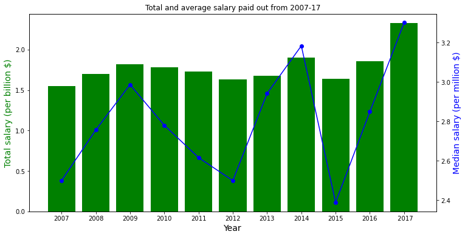

```python
## How total and average salary changed over time

bar = []
line = []
for i in range(0,11):
    y = sum(salaries.dropna().iloc[:,i])/1000000000
    bar.append(y)
    y = median(salaries.dropna().iloc[:,i])/1000000
    line.append(y)

season = ['2007','2008','2009','2010','2011','2012','2013','2014','2015','2016',' 2017']

fig,ax = plt.subplots(figsize=(12,6))
ax.bar(season, bar, color="green")
ax.set_xlabel("Year",fontsize=14)
ax.set_ylabel("Total salary (per billion $)",color="green",fontsize=14)

ax2=ax.twinx()
ax2.plot(season, line,color="blue",marker="o")
ax2.set_ylabel("Median salary (per million $)",color="blue",fontsize=14)

ax.set_title("Total and average salary paid out from 2007-17")
plt.show()
```

Lastly, while both total salary and median salary trends mirror each other, the changes in both variables are not proportional to each other. Median salary seems to have a slightly greater sensitivity and variability from year to year. Nonetheless, an increase in total salary seems to benefit all players as it usually results in an increase of median salaries for every player.

### 5.3 Inequality of salary over time

We are also interested in the change in inequality of salary distribution over the years. Distribution of salaries is visualised in multiple boxplots.

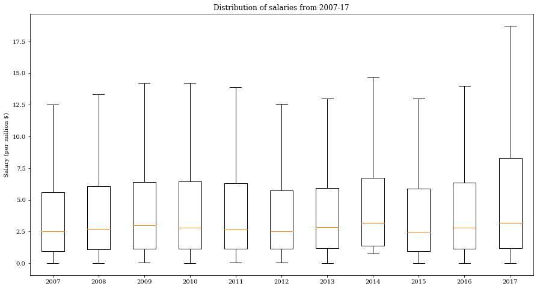

```python
## How distribution of salary changed over time
seasons={}
s = [2007, 2008, 2009, 2010, 2011, 2012, 2013, 2014, 2015, 2016, 2017]
for i in range(0,11):
    season = s[i]
    seasons[season]=salaries.iloc[:,i].dropna().apply(lambda x: x / 1000000)
fig, ax = plt.subplots(figsize=(15,8))
ax.boxplot(seasons.values(), showfliers=False)
ax.set_ylabel('Salary (per million $)')
ax.set_xticklabels(seasons.keys())
ax.set_title("Distribution of salaries from 2007-17")
plt.show()
```

As we can see, the general shape of the boxplots remained constant throughout the years - a long top whisker and a short bottom whisker. The middle 50% of salaries remain relatively equal in size (no extreme variations in average salary over the years), although some years, such as 2007, 2012, 2013 and 2015, see a smaller variation. These correspond with smaller total salary expenditure in the previous bar graph, which could mean that a lower total salary leads to less variations in the average player salary. Hence, it can be hypothesised that total salary increases are pushed by star players obtaining big contracts. Indeed, this theory would reconcile increasing total salaries and increasing wage inequality.

Another exception is the distribution of salaries in 2017. It is a lot more unequal than the preceding seasons. Indeed, even though the middle 50% of salary distribution is on a relatively equal level albeit over a larger range, the maximum salary (excluding outliers) increased from 14 to 19 million dollars and the upper whisker which represents the top 25% of salaries grew longer. This indicates that a few players earned a lot more money while the rest of the league did not see a proportional increase.

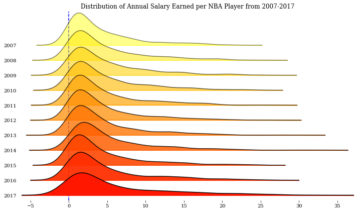

```python
## Joyplot of salaries over time
joyplot(salaries/1000000, colormap=cm.autumn_r, kind='kde', fade=True, range_style='own', tails=0.2,
        background='w', figsize = (10,6), title = 'Distribution of Annual Salary Earned per NBA Player from 2007-2017')
plt.axvline(x=0, color='blue', ls='--')
plt.show()
```

We see this inequality clearly in the above ridgeline plot as well. The longer and thicker tail of the 2017 season, as well as the lower maximum peak of the density plot, supports the above conclusion that wage inequality grew in 2017. In this plot, it is clearer which seasons see greater inequality in their salary distribution as it allows us to see the distribution without being categorised into quantiles like in the box plot. Seasons with a shorter right tail such as 2010 and 2015 see a less unequal salary distribution. This is a useful added dimension as from the previous box plot, the distribution of salary in 2009 and 2010 seems similar. However, the density plots reveal a slight decrease in inequality in 2010. Overall, there does not seem to be a consistent trend of improving or worsening inequality in salary distribution; it varies from season to season, though it is clear that the NBA salary distribution has always been highly unequal in nature.

## 6 Conclusion

This report set out to find the hidden secret determinants of NBA salaries and what they could tell us about professional basketball players. The determinants of the salaries of professional sports players has always been a mystery. It was thus very insightful to search for the formula of an NBA player’s salary.

Some themes briefly mentioned in this report could be explored in more depth. For one, the growth of international representation is one that we are particularly interested in. Indeed, the growing popularity of basketball outside of the US has opened up the league to a vast new pool of talents. New data science techniques could be applied to model and predict the evolution of foreign players in the sport and their impact on the league. How will the proportion of foreign players change in the coming years? Will the NBA be able to remain attractive to these foreign talents? How will the league’s marketing strategies evolve to reach an ever growing foreign fan base?

## 7 References

- Berri, D (2012) ‘Measuring Performance in the National Basketball Association’ in Leo, H. K. and Shmanske, S. (eds) The Oxford Handbook of Sports Economics: Economics Through Sports, Oxford Handbooks Online, 2.
- Cash, M. and S. Gal (2018) ‘NBA’s trend of increasing number of international players appears to be slowing down’ (WWW) Insider (https://www.businessinsider.com; 16 October 2018).
- Coon, L (2011) ‘Breaking down changes in new CBA’ (WWW) ESPN (https://www.espn.com; 24 January 2022).
- Modi, D . (2018) ‘Modelling the Labor Economics of the NBA’, paper published by Northwestern University.
- Philip, S (2020) ‘The Growth of International Players in the NBA’ (WWW) Samford University (https://www.samford.edu; 24 January 2022).
- Quinn, S (2020) ‘Scottie Pippen contract explained: How the Bulls managed to sign Hall of Famer for pennies of the dollar’ (WWW) CBS SPORTS (https://www.cbssports.com; 24 January 2022).
- Statista (2022) ‘National Basketball Association total league revenue from 2001/02 to 2019/20’ (WWW) Statista (https://www.statista.com; 24 January 2022).
- Stanek, T. (2016) ‘Player Performance and Team Revenues: NBA Player Salary Analysis”, CMC Senior Theses, Paper 1257.
- World Population Review (2021) ‘Gini Coefficient by Country 2021’ (WWW) World Population Review (https://worldpopulationreview.com; 24 January 2022).

## 8 Contribution

In general, all members were equally involved and contributed to the best of our ability, depending on what we are each comfortable with and confident in. We also helped each other and troubleshot together when faced with errors running the code.

- Formulation of research question: All members assisted in the formulation of the research question during our discussions and meetings before agreeing on our main research question and sub-questions.
- Webscaping:
  - Member 1: player links, time series data
  - Member 2: salary data for all seasons
  - Member 3: basic statistics of players, season specific data
- Cleaning: All members cleaned and organised data during the data collection and manipulation stages. Data cleaning was done all throughout the project.
- Visualisation:
  - Member 1: lorenz curve, radar plot, time series plots
  - Member 2: salary box plot and violin plot, salary scatterplot by experience and positions
  - Member 3: box plots by positions and teams, nationality plots, sankey diagram, ridgeline plot
- Data modelling:
  - Member 2: regression, k-means clustering
- Report write-up: All members wrote the analysis for the parts that each worked on. We then went over each other’s analysis write-up and edited to include our own contributions and ensure the report flows.